# subset gridded data as geotiff and plot

Jordan Read, Alison Appling

21 August, 2018

`geoknife` has a number of output formats, but a new one that was added in version 1.1.0 of the package (after the initial release to CRAN) is the ability to output results as a zip file that contains a series of geotiffs for each timestep requested. This vignette is a brief introduction on how to do this using a few additional packages that are in the `Suggests` field in the description.

## get the data

see the `geoknife` getting started vignette for more details, but for the purposes of this vignette, we need to get some data first and then plot it up.  
First things first, load up the `geoknife` package

```r
library(geoknife)
```

For this example, I am going to use a dataset that is hosted by NASA, and includes a number of radiation estimates for various components. There is a lot of global data here, but I am just going to pluck a subset in time (one timepoint for the month of July of one year) and a spatial subset. I am going to use the `OUTPUT_TYPE='geotiff'` argument that was added in version 1.1.0 of `geoknife`. We are relying on a NASA dataset here, so apologies if they change the url in the future and this doesn’t work…

```r
knife <- webprocess(algorithm = list('OPeNDAP Subset'="gov.usgs.cida.gdp.wps.algorithm.FeatureCoverageOPeNDAPIntersectionAlgorithm"))
fabric <- webdata(url='dods://opendap.larc.nasa.gov/opendap/hyrax/SortByProduct/CERES/EBAF/Surface_Edition2.8/CERES_EBAF-Surface_Edition2.8_200003-201506.nc',
                  variable="sfc_sw_down_all_mon", #Surface Shortwave Flux Down, Monthly Means, All-Sky conditions
                  times=c('2014-07-15','2014-07-15'))
stencil <- simplegeom(data.frame('point1' = c(-5,32), 'point2' = c(-90,-78))) # big 'ol chunk 'o data
job <- geoknife(stencil, fabric, knife, wait = TRUE, OUTPUT_TYPE = "geotiff")
```

now that the job is complete (because `wait=TRUE` was used), we can download the result and unzip it:

```r
file <- download(job, destination = file.path(tempdir(), 'nasa_data.zip'), overwrite=TRUE)
unzip(file, exdir=file.path(tempdir(),'NASA'))
tiff.dir <- file.path(tempdir(),'NASA')
```

## plot the data

using the `rasterVis` package, read this in and create a raster object:

```r
library(rgdal)
library(rasterVis)
nasa <- raster(file.path(tiff.dir , dir(tiff.dir)))
```

Now, use `ggplot2` and `ggmap` to plot this as a map:

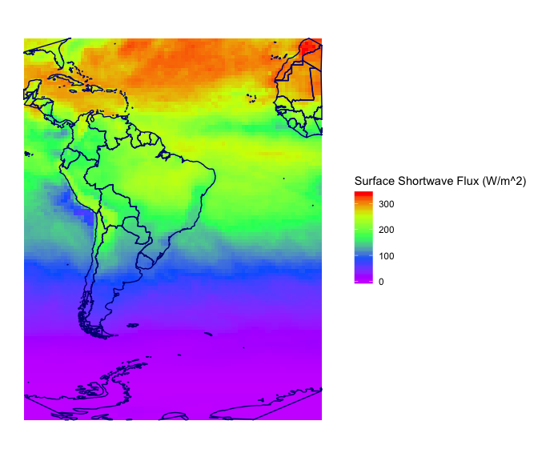

```r
library(maps)
library(ggmap)
library(ggplot2)



world <- map_data("world2")
gplot(nasa, maxpixels = 5e5) +
  geom_tile(aes(fill = value), alpha=1) +
  geom_polygon(data=world, aes(x=long, y=lat, group=group), color="navy", fill='transparent') +
  scale_fill_gradientn("Surface Shortwave Flux (W/m^2)", colours=rev(rainbow(5))) +
  coord_equal() +
  theme_classic() +
  theme(axis.line = element_blank(), axis.text.x = element_blank(), axis.text.y = element_blank(),
        axis.ticks = element_blank(), axis.title.x = element_blank(), axis.title.y = element_blank()) +
  scale_y_continuous(limits=c(nasa@extent@ymin, nasa@extent@ymax)) +
  scale_x_continuous(limits=c(nasa@extent@xmin, nasa@extent@xmax))
```